# communities library - Rings of Cliques

## Overview

This vignette shows how to create **Ring-of-Cliques (ROC)** test graphs using `make_ring_of_cliques()` with four variants:

- **RC**
- **RC_B** — ring bridges between adjacent cliques
- **RC_C** — one central node connected to each clique
- **RC_BC** — both ring bridges **and** central node

Each clique is a ground-truth community. The function annotates vertices with: - `gt_community` (numeric), `gt_label` (character), - `clique_id`, `within_id`, - role flags (`role`, `is_bridge_endpoint`, `is_center_endpoint`).

Graphs are constructed deterministically: all clique vertices come first, the optional center (if any) is last.

## Quick start

```r
library(tidyverse)
library(knitr)   # for kable()
library(igraph)
library(communities)
```

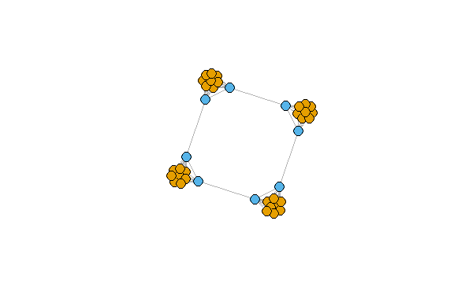

```r
g  <- communities::make_ring_of_cliques(
    n_cliques = 4,
    clique_size = 10,
    variant = "RC"
)

plot(
  g,
  vertex.color = degree(g),
  vertex.label = NA,
  vertex.size = 15,
  edge.color = "grey70",
)
```

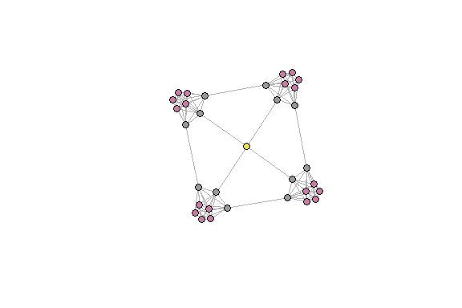

```r
g  <- communities::make_ring_of_cliques(
    n_cliques = 4,
    clique_size = 8,
    variant = "RC_C"
)

plot(
  g,
  vertex.color = degree(g),
  vertex.label = NA,
  vertex.size = 10,
  edge.color = "grey70",
)
```

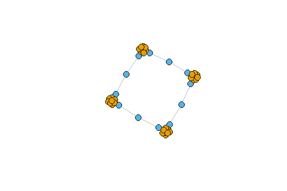

```r
g  <- communities::make_ring_of_cliques(
    n_cliques = 4,
    clique_size = 10,
    variant = "RC_B"
)

plot(
  g,
  vertex.color = degree(g),
  vertex.label = NA,
  vertex.size = 15,
  edge.color = "grey70",
)
```

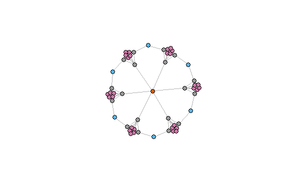

```r
g  <- communities::make_ring_of_cliques(
    n_cliques = 6,
    clique_size = 8,
    variant = "RC_BC"
)

plot(
  g,
  vertex.color = degree(g),
  vertex.label = NA,
  vertex.size = 10,
  edge.color = "grey70",
)
```

## Ground-truth labels

Each clique is assigned to a “truth community”; outliers are assigned to community “0”:

```r
g  <- communities::make_ring_of_cliques(
    n_cliques = 6,
    clique_size = 8,
    variant = "RC_BC"
)
# Each node belongs to a community identified by its "gt_community" attribute.
# Here we count how many nodes are in each community.
comm_dist <- tibble(
  community = V(g)$gt_community
) %>%
  count(community, name = "n_nodes") %>%
  arrange(desc(n_nodes))

kable(comm_dist, caption = "Distribution of ground-truth communities")
```

Distribution of ground-truth communities

| community | n_nodes |
| --- | --- |
| 1 | 8 |
| 2 | 8 |
| 3 | 8 |
| 4 | 8 |
| 5 | 8 |
| 6 | 8 |
| 0 | 7 |

```r
NA
NA
NA
```

```r
# --- Outlier nodes (if present) ---
# Nodes with gt_community = 0 are considered outliers and are labelled "CENTRAL".
# We extract and display only these nodes for inspection.
outliers <- tibble(
  node = V(g)$name,
  community = V(g)$gt_community
) %>%
  filter(community == 0)

kable(outliers, caption = "List of outlier nodes (community = 0)")
```

List of outlier nodes (community = 0)

| node | community |
| --- | --- |
| bridge1 | 0 |
| bridge2 | 0 |
| bridge3 | 0 |
| bridge4 | 0 |
| bridge5 | 0 |
| bridge6 | 0 |
| center | 0 |

You can inspect roles and edge types:

```r
sort(table(V(g)$role))
```

```
central  bridge  clique
      1       6      48
```

```r
sort(table(E(g)$edge_type))
```

```
center_spoke  bridge_edge intra_clique
           6           12          168
```

## Takeaways

- Each clique is annotated with a unique ground-truth label.
- Variants (RC_B, RC_C, RC_BC) change the meso-structure without altering the inner cliques.
- The construction is deterministic and idempotent: given the same parameters, you always obtain the same graph structure and vertex order.

This makes the functions suitable for benchmarking community detection algorithms under controlled conditions.